Uppföljning av strategier och planer

# Uppföljning av strategier och planer

Rapporten är skapad av Samhällsanalys, Region Dalarna  
Senast uppdaterad: 2026-10-30

# 1 Introduktion

I den här rapporten samlar Region Dalarna redovisningar av läget för utvecklingen i Dalarna utifrån de olika områdesstrategier som utgör delstrategier till den samlade regionala utvecklingsstrategin [“Dalastrategin - Tillsammans för ett hållbart Dalarna”](https://www.regiondalarna.se/globalassets/regional-utveckling/dalastrategin-2030-tillsammans-for-ett-hallbart-dalarna-dec.pdf).

I denna första upplaga redovisas resultatet för energi- och klimatstrategin. Rapporten är under uppbyggnad.

# 2 Energi- och klimatstrategin

Det övergripande målet för Dalarnas energi- och klimatstrategiska arbete är att skapa förutsättningar för hållbar utveckling på regional och lokal nivå, och därigenom bidra till att de nationella energi- och klimatmålen uppnås. I strategin finns mål, aktiviteter och indikatorer angivna. Denna rapport visar på förändringen över tid för strategins utvalda indikatorer. Samtidigt kan indikatorerna inte på egen hand visa vilken betydelse strategin har haft för utvecklingen. Uppföljningen kompletteras därför med en översikt av ett urval genomförda aktiviteter och insatser. Forskning om utvärdering och styrning visar att bedömningar av en strategis effekter kräver en bredare analys där resultat, genomförande, omvärldsfaktorer och samband mellan olika åtgärder vägs samman. Med längre intervall behöver därför fördjupade analyser genomföras för att bedöma strategins bidrag till utvecklingen i länet. Energi- och klimatomställningen är dessutom nära sammanlänkad med ekologisk, social och ekonomisk hållbarhet, vilket innebär att utvecklingen inom ett område både påverkar och påverkas av utvecklingen inom andra.

Arbetet med att genomföra Energi- och klimatstrategin bedrivs inom samverkans nätverket Energiintelligent Dalarna. Energiintelligent samlar aktörer inom energi- och klimatarbetet för att kunna växla upp arbetet mot våra energi- och klimatmål.

Detta är en sammanställning av de indikatorer som har valts inom arbetet med Energi- och klimatstrategin för Dalarna. Indikatorerna beskriver utvecklingen på samhällsnivå inom områden som bedömts vara viktiga för omställningen och ger en bild av hur läget förändras över tid. Samtidigt kan indikatorerna inte på egen hand visa vilken betydelse strategin har haft för utvecklingen. Uppföljningen kompletteras därför med en översikt av ett urval genomförda aktiviteter och insatser. Forskning om utvärdering och styrning visar att bedömningar av en strategis effekter kräver en bredare analys där resultat, genomförande, omvärldsfaktorer och samband mellan olika åtgärder vägs samman. Med längre tidsintervall behöver därför fördjupade analyser genomföras för att bedöma strategins bidrag till utvecklingen i länet. Energi- och klimatomställningen är dessutom nära sammanlänkad med ekologisk, social och ekonomisk hållbarhet, vilket innebär att utvecklingen inom ett område både påverkar och påverkas av utvecklingen inom andra.

Uppföljning av strategin sker genom följande åtta indikatorer fördelade på sju avsnitt.

- Totala växthusgasutsläpp, ton CO₂e
- Konsumtionsbaserade utsläpp, ton CO₂e/invånare.
- Utsläpp av växthusgaser per sektor (industri, transporter, bostäder och lokaler, arbetsmaskiner, jordbruk och övrigt, ton CO₂e.
- Energiproduktion och energianvändning, GWh per år, varav fossilfri energi.
- Elproduktion och elanvändning, GWh per år.
- Energieffektivitet; BRP per ton utsläpp CO₂e.
- Resor per invånare med kollektivtrafik.
- Mängd insamlat kommunalt avfall per person.

## 2.1 Totala växthusgasutsläpp samt per sektor

Utsläppen av växthusgaser är i huvudsak en följd av samhällets användning av fossila bränslen och är den grundläggande orsaken till den pågående klimatförändringen. Målen i Dalarna ligger i linje med de nationella klimatmålen, med sikte på nettonollutsläpp senast 2045. Samtidigt är det inte bara målåret som är avgörande, utan även hur snabbt utsläppen minskar på vägen dit. Eftersom klimatpåverkan beror på den samlade mängden växthusgaser som släpps ut över tid kan tidiga utsläppsminskningar ge större nytta än motsvarande minskningar längre fram. Ur ett klimatbudgetperspektiv är därför den totala mängden utsläpp fram till måluppfyllelse minst lika viktig som att nå själva slutmålet.

De klimatpåverkande växthusgaserna innefattar fler ämnen än koldioxid. Ett exempel är metangas som även är betydligt skadligare per enhet än koldioxid (1 ton metangas motsvarar utsläpp av ca 28 ton koldioxid). För att utsläppen som sker i Dalarna ska vara jämförbara med andra regioners utsläpp omsätts därför samtliga gasers utsläpp till så kallade koldioxidekvivalenter, det vill säga den mängd som varje ämne släpper ut omräknat i termer av koldioxid.

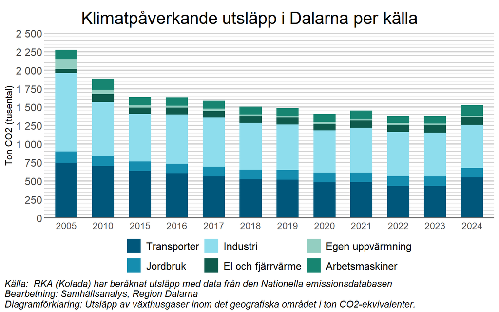

Sett till utsläpp per person ligger Dalarna högre än riksgenomsnittet, trots en minskning från knappt 8,3 ton/invånare år 1990 till ungefär 5,5 ton/invånare år 2024. För att uppnå målet om klimatneutralitet 2045, skulle utsläppen behöva minska till ca 1,25 ton/invånare år 2045, vilket innebär en minskning om ungefär 7 procent årligen mellan 2024 och 2045. Som jämförelse minskade utsläppen per person i Dalarna med ungefär 1 procent per år mellan 2015 och 2024. Även om vi ser en utveckling i rätt riktning kommer det således att krävas en ännu snabbare minskningstakt för att uppnå våra ambitioner i Dalastrategin och bli klimatneutrala till år 2045 i enlighet med den nationella målsättningen.

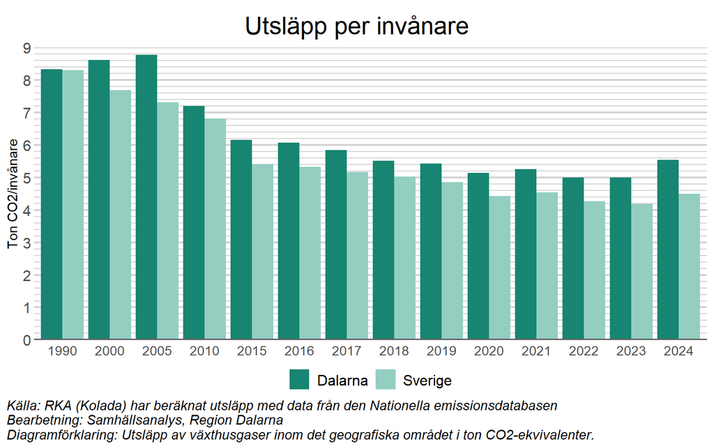

## 2.2 Konsumtionsbaserade utsläpp

De utsläpp som sker inom Dalarnas gränser speglar inte hela länets klimatpåverkan. En del av utsläppen är kopplade till produktion av varor och tjänster som exporteras och används på andra platser. Samtidigt ger vår konsumtion upphov till utsläpp i andra delar av Sverige och världen, där de varor och tjänster vi använder produceras. För att få en mer heltäckande bild av klimatpåverkan behöver utsläppen därför också betraktas ur ett konsumtionsperspektiv – det vill säga de utsläpp som orsakas av våra val och vår efterfrågan, oavsett var i världen de faktiskt sker.

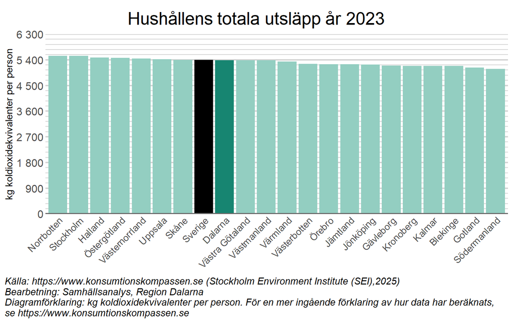

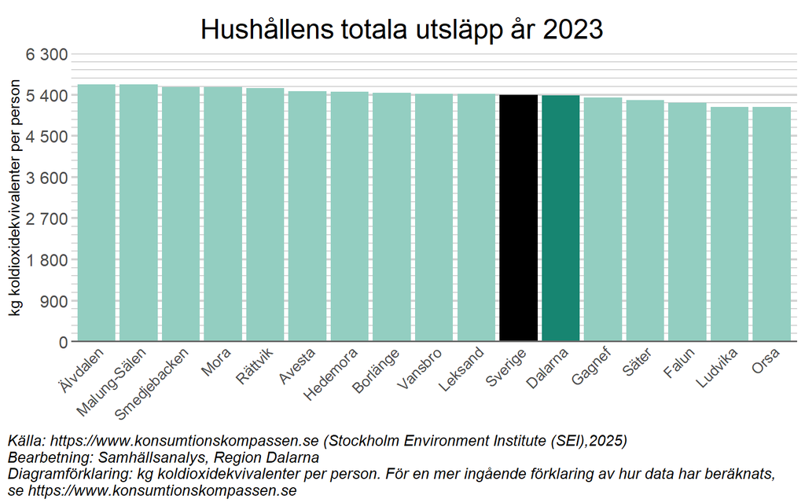

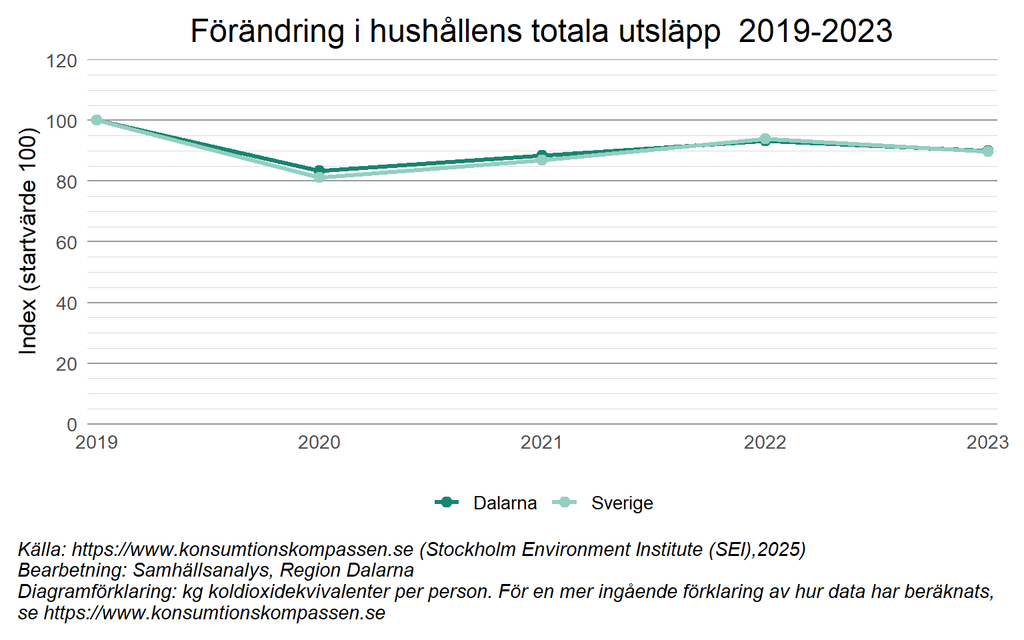

## 2.3 Mängd insamlat kommunalt avfall per person

Mängden kommunalt avfall per person är en indikator på hur effektivt samhället använder sina resurser. En minskad avfallsmängd kan tyda på förändrade konsumtionsmönster, ökad återanvändning och längre livslängd på produkter, medan ökande avfallsmängder ofta innebär ett större uttag av råvaror och högre belastning på klimat och miljö. Indikatorn fångar därmed en viktig del av omställningen till ett mer resurseffektivt och cirkulärt samhälle. Även om avfallshanteringen i sig påverkar klimatet är indikatorns främsta värde att den speglar den underliggande konsumtion som driver både materialanvändning, energibehov och utsläpp av växthusgaser, i Dalarna och globalt.

I det kommunala avfallet ingår det mesta avfall som ett hushåll producerar, så som mat- och restavfall, grov- och trädgårdsavfall och farligt avfall. Även förpackningar och batterier etc. som ingår i producentansvaret ingår i beräkningen. I sammanställningen nedan visas insamlat kommunalt avfall per person och år i Dalarna från 2013 till 2024. År 2013 samlades det in 497 kg avfall per person i Dalarna, att jämföra med ca 453 kg per person år 2024. En lägre mängd per person signalerar en lägre resursanvändning. I en nationell jämförelse ses att Stockholms län ligger bäst till med ungefär 388 kg per person och år, medan Värmland ligger sämst till med ca 511 kg per person och år.

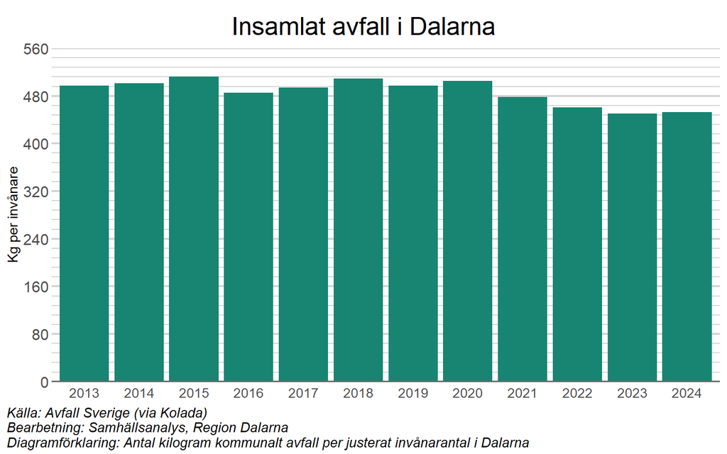

## 2.4 Energiproduktion och energianvändning

Energisystemet utgörs av tre delar; tillförsel, omvandling och användning av energi. Hur hållbart energisystemet är påverkas därför både av vilken energi som tillförs, exempelvis solkraft, olja eller kärnkraft, hur energin omvandlas till användbar form, så som el, värme och drivmedel, och hur energin sedan används, och vilka förluster som uppstår vid omvandling och förbrukning. En nationell överblick över detta finns på [“Energimyndighetens hemsida”](https://www.energimyndigheten.se/energisystem-och-analys/sveriges-energisystem/hur-fungerar-energisystemet/sveriges-energisystem/).

Omställningen av energisystemet från fossila till fossilfria energikällor är avgörande för att nå klimatmålen och samtidigt stärka Dalarnas långsiktiga konkurrenskraft. Tillgången till fossilfri energi blir en allt viktigare faktor för näringslivets utveckling, inte minst när företag ska minska sina utsläpp, elektrifiera verksamheter och möta ökade krav från kunder, investerare och lagstiftning. Efterfrågan på fossilfri el och andra fossilfria energibärare ökar snabbt, och regioner som kan erbjuda en stabil och hållbar energiförsörjning har goda förutsättningar att attrahera investeringar, nyetableringar och innovation. Samtidigt behöver energianvändningen bli mer resurseffektiv för att den tillgängliga energin ska räcka till både omställning och fortsatt samhällsutveckling. Utvecklingen av såväl energiproduktion som energianvändning är därför central att följa i arbetet med energi- och klimatstrategin.

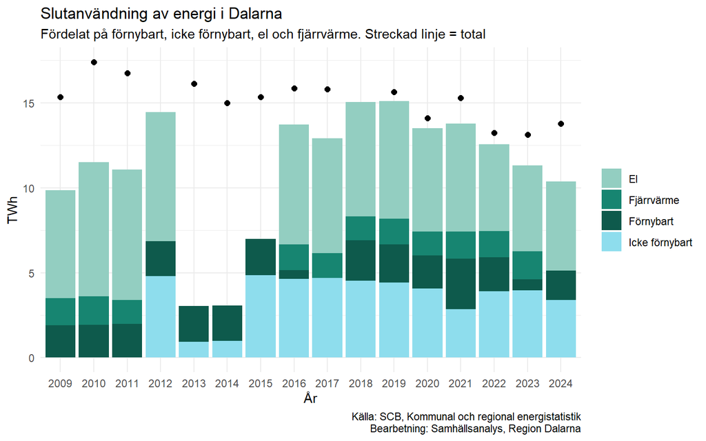

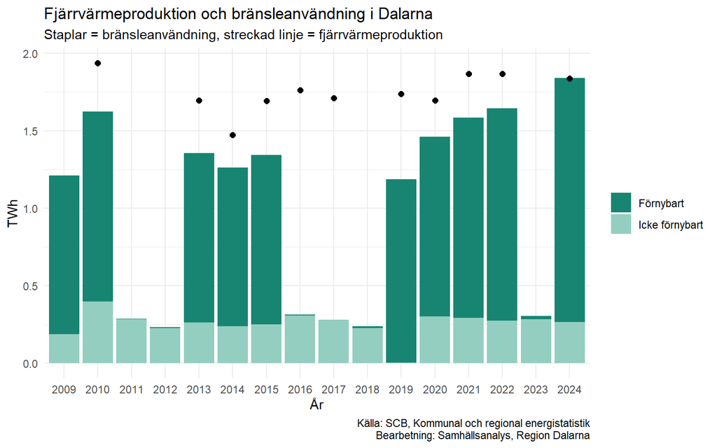

## 2.5 Elproduktion och elanvändning

Elektrifieringen är en av de viktigaste drivkrafterna i energi- och klimatomställningen. För att minska utsläppen behöver fossila bränslen i transportsektorn, industrin och delar av uppvärmningen ersättas med el producerad av hållbara energislag eller andra fossilfria energibärare. Detta medför en snabbt växande efterfrågan på el, samtidigt som kraven på ett robust och flexibelt elsystem ökar. Utvecklingen av både elanvändning och elproduktion är därför central att följa. En hög grad av regional elproduktion bidrar till att stärka försörjningstryggheten, minska sårbarheten och skapa bättre förutsättningar för att möta framtidens elbehov. Att Dalarna kan vara, och fortsätta vara, en region med en hög grad av självförsörjning på el är därför betydelsefullt både för omställningen och för länets långsiktiga utveckling.

Produktionen av el i Dalarna varierar mellan olika år, bland annat beroende på om det är torrår eller våtår (se exempelvis år 2018 som var ett ovanligt torrt år). I diagrammet visas mängden el producerad av vindkraft respektive vattenkraft och övrigt. I kategorin övrigt ingår exempelvis kraftvärmeverk och industriellt mottryck, och sedan år 2021 även solkraft.

Även elproduktionen från solkraft, som är en del av kategorin vattenkraft och övrigt i diagrammet nedan, har ökat tydligt i Dalarna på senare år, från ungefär 26 900 MVh år 2021 till ca 118 400 MVh år 2024. Trots ökningen stod solkraft bara för 2 procent av den totala elproduktionen i Dalarna år 2024.

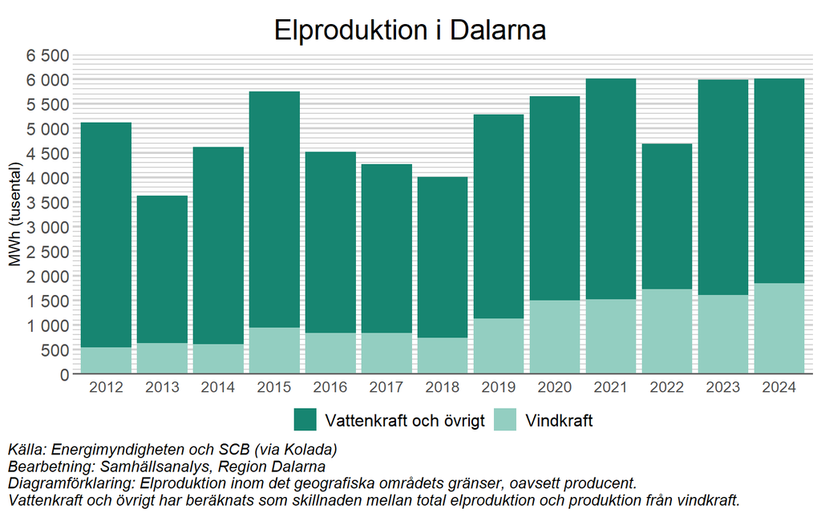

I diagrammet nedan visas en teoretisk beräkning av självförsörjning av elektricitet i Dalarna där den totala elproduktionen i länet visas som andel av den total elförbrukningen. Diagrammet visar en positiv trend för självförsörjningsgraden av elektricitet.

Att självförsörjningsgraden har ökat tydlligt på senare år, mer el producerades i länet än den som konsumerades säväl 2023 som 2024, beror i första hand på att konsumtionen av el har minskat, något som potentiellt delvis kan förklaras av Rysslands invasion av Ukraina och dess effekt på elpriserna. Konsumtionen av el var ovanligt låg även 2022, men då var även produktionen av el i länet ovanligt liten (se fliken förnybar elproduktion).

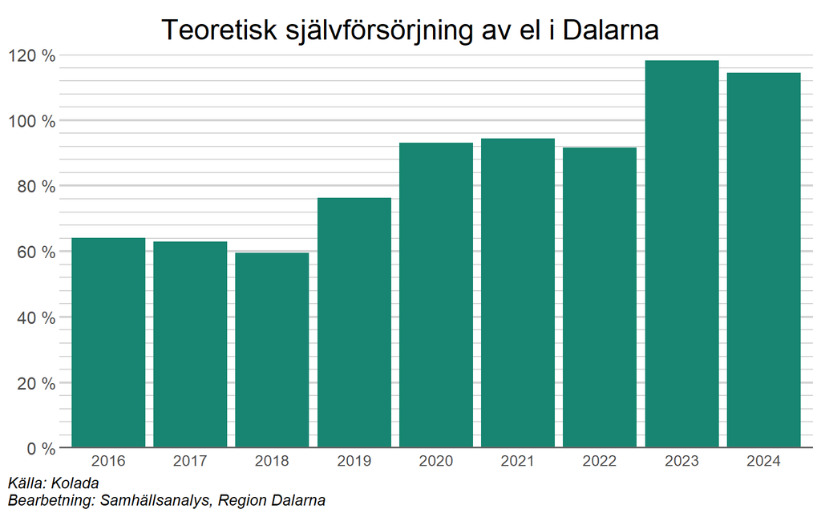

## 2.6 Energieffektivitet

En mer effektiv användning av energi är en av de mest kostnadseffektiva vägarna i energi- och klimatomställningen. Trots teknisk utveckling finns fortfarande betydande potential att minska energislöseri i byggnader, transporter och industri. Genom att använda energi smartare kan samma eller högre värde skapas med mindre resursinsats. Indikatorn BRP per ton koldioxidutsläpp beskriver hur väl ekonomiskt värdeskapande frikopplas från klimatpåverkan. En ökande kvot innebär att länets ekonomi utvecklas samtidigt som utsläppen minskar, vilket är ett tecken på ökad resurs- och energieffektivitet. Att skapa mer välfärd och ekonomiskt värde med lägre energianvändning och mindre klimatpåverkan är en central del av omställningen till ett konkurrenskraftigt och hållbart samhälle.

Elektrifieringen är en av de viktigaste drivkrafterna i energi- och klimatomställningen. För att minska utsläppen behöver fossila bränslen i transportsektorn, industrin och delar av uppvärmningen ersättas med el eller andra fossilfria energibärare. Detta medför en snabbt växande efterfrågan på el, samtidigt som kraven på ett robust och flexibelt elsystem ökar. Utvecklingen av både elanvändning och elproduktion är därför central att följa. En hög grad av regional elproduktion bidrar till att stärka försörjningstryggheten, minska sårbarheten och skapa bättre förutsättningar för att möta framtidens elbehov. Att Dalarna kan vara, och fortsätta vara, en region med en hög grad av självförsörjning på el är därför betydelsefullt både för omställningen och för länets långsiktiga utveckling.

Ett sätt att mäta den ekonomiska effektiviteten i energianvändningen är att sätta utsläppen som genereras i länet i relation till de ekonomiska värden som produceras med energin. En regions ekonomiska värdeproduktion mäts genom bruttoregionalprodukten (BRP). Energins ekonomiska effektivitet skattas sedan genom att beräkna förädlingsvärdet per ton koldioxidekvivalenter, vilket kopplar ihop utsläppen i länet med den ekonomiska aktiviteten. Att få ut ett större ekonomiskt värde av varje använd energienhet antas innebära en lägre miljöbelastning per producerad krona, och ses därför generellt som positivt.

I Dalarna utgörs samtidigt en stor del av näringslivet av tillverkande industri som förbrukar relativt sett stora mängder energi och driver därigenom upp mängden energi förbrukad per invånare.

Ett ökat förädlingsvärde per mängd förbrukad energi i länet kan betyda att länet har förbättrat energieffektiviteten i de fall industrier och näringar är ungefär desamma mellan mätningarna. En förklaring till en förbättrad energieffektivitet kan annars vara att näringslivets struktur har förändrats i en riktning där energikrävande industrier har lämnat regionen och mer kunskapsintensiv tjänsteproduktion har ökat (som generellt kräver mindre energi). Om energikrävande industrier har lämnat regionen och skapar utsläpp i andra delar av världen är det tyvärr inte självklart att nettoeffekten på de globala utsläppen minskat, då de flesta andra länder har en svagare miljölagstiftning än Sverige.

Mellan 2008 och 2022 ökade energieffektiviteten i ekonomiska termer i Dalarna med ca 108 procent. Förändringen beror framförallt på att utsläppen av växthusgaser i länet har minskat under perioden men även på att BRP för Dalarna har stigit under samma tidsperiod.

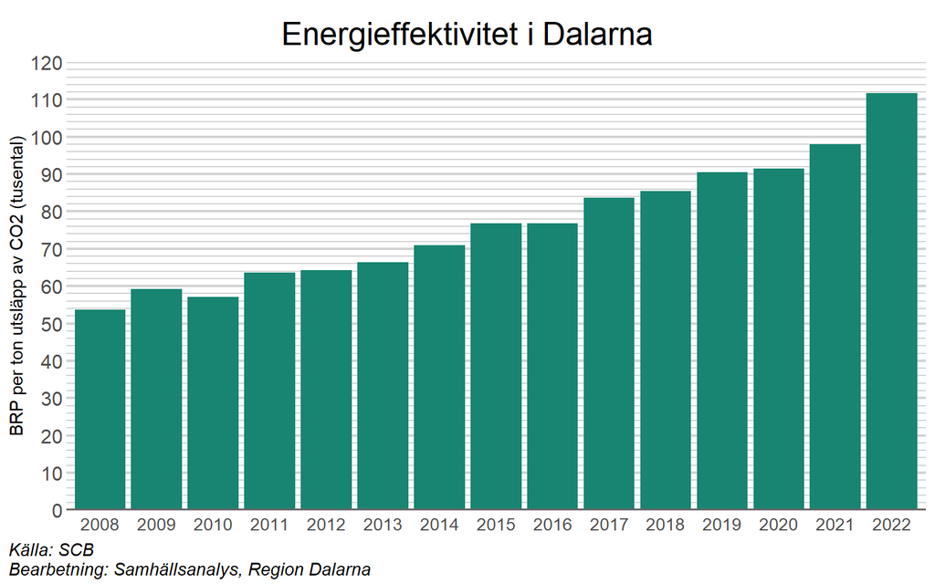

I en nationell jämförelse ligger Dalarnas energieffektivitet på den sämre halvan av intervallet tillsammans med regioner som också är mer glest befolkade och har tunga industrier.

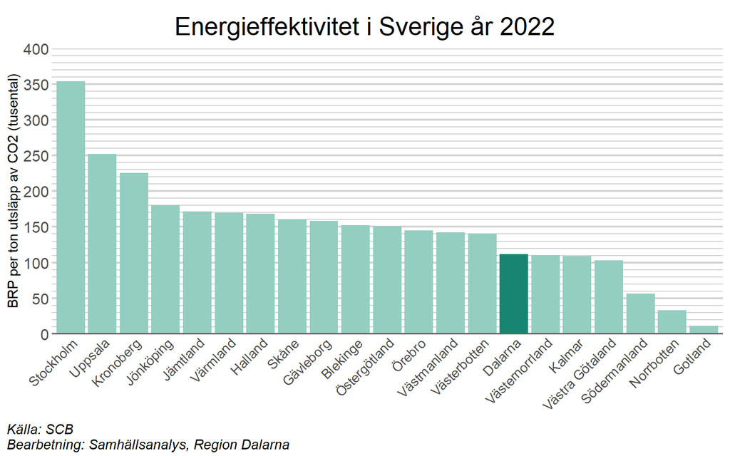

## 2.7 Resor per invånare med kollektivtrafik

Transportsektorn står för en betydande del av utsläppen av växthusgaser, och personbilstrafiken utgör den största delen av dessa utsläpp. Elektrifieringen av fordonsflottan är en viktig och nödvändig del av omställningen, men för att minska klimatpåverkan, energianvändningen och trängseln i transportsystemet behöver även beroendet av bilen minska. Kollektivtrafiken spelar därför en central roll genom att erbjuda ett mer transporteffektivt sätt att förflytta människor. Ett ökat kollektivresande kan bidra till minskade utsläpp, ett effektivare nyttjande av infrastruktur och bättre tillgänglighet för fler grupper i samhället. Indikatorn ger därmed en bild av utvecklingen mot ett mer hållbart transportsystem, där resbehov kan tillgodoses med lägre resursanvändning och klimatpåverkan.

Den utsträckta och relativt glesbefolkade geografin i Dalarna är utmaningar i arbetet med att skapa en hållbar transportinfrastruktur. För att transportsektorn ska nå klimat- och energimålen krävs kraftfull teknisk utveckling i kombination med beteendeförändringar så som minskad konsumtion av varor vars transporter orsakar höga utsläpp, ökad samåkning och minskat resande totalt sett. Kollektivt resande spelar en central roll för utvecklandet av en klimatsmart och resurseffektiv, men också mer jämlik, mobilitet. Kollektivtrafik bidrar både till miljönytta och samhällsekonomisk effektivitet men är också förenat med höga kostnader. För att klara omställningen krävs mod att ställa olika kostnader mot varandra. För att det kollektiva resandet ska öka behöver den traditionella kollektivtrafiken sannolikt kompletteras med nya mobilitetslösningar och tjänster, särskilt för länets mest glesbefolkade områden.

Diagrammen redovisar indikatorer för kollektivt resande i Dalarna: Kollektivtrafiksresor per invånare samt marknadsandel för kollektivtrafik i länet. För antal resor per invånare syns att det kollektiva resandet har minskat avsevärt i Dalarna, från 48 resor per person och år 2010 till knappt 32 resor år 2025. Nedgången kan delvis förklaras av pandemin - det sker en tydlig minskning mellan 2019 och 2020 - men även mellan 2012 och 2013 minskade antalet resor per invånare avsevärt i Dalarna. I en nationell jämförelse år 2024 framgår att det i glesbygdslänen i Sverige som mest görs runt 60 resor per person, medan det görs betydligt fler i storstadsregionerna, så som Skåne med i snitt 122 resor per person och år. I Stockholm där flest resor sker, görs 306 resor per person och år. I jämförelse med Sveriges övriga län görs näst minst antal resor med kollektivtrafik per invånare i Dalarna. Bara på Gotland görs färre resor (Kolada).

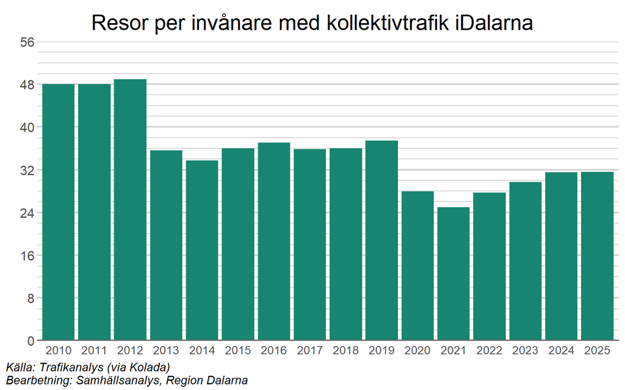

Marknadsandelen för kollektivtrafik beräknas som andelen resor med kollektivtrafik (linjelagd buss, spårvagn, tunnelbana, pendeltåg, tåg och båt) och taxi av det totala antalet resor, dvs kollektivtrafik, taxi, bil (förare och passagerare) samt moped/MC. Efter ett antal år av ökande marknadsandel för kollektivtrafiken bröts uppgången år 2020 av en förmodad pandemieffekt. Nedgången fortsatte år 2021 när marknadsandelen för kollektivtrafik bara var 6 procent. Därefter ökade marknadsandelen under ett par år, innan den minskade igen år 2024. Sett över hela tidsperioden 2010 till 2024 har marknadsandelen för kollektivtrafik minskat med 1 procentenhet, från 10 procent år 2010 till 9 procent år 2024.

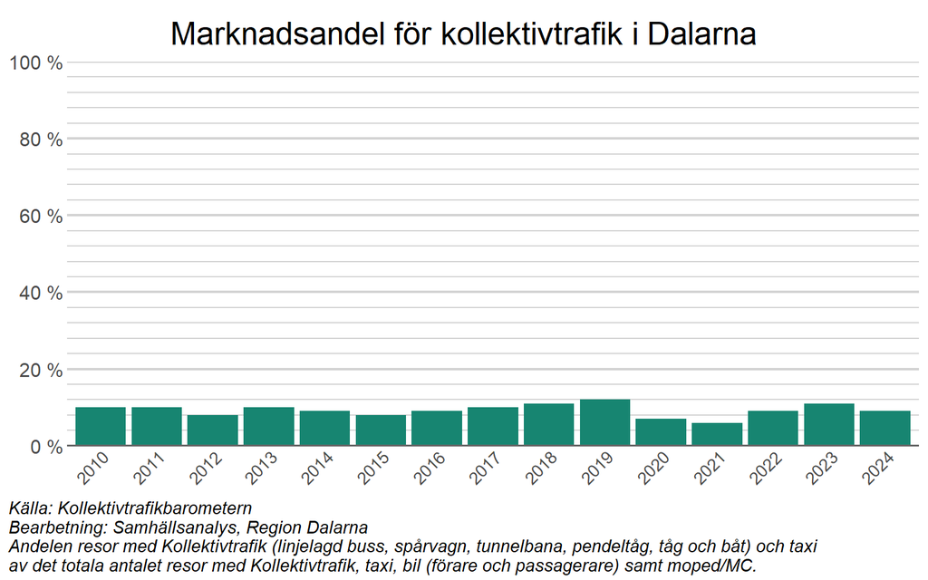